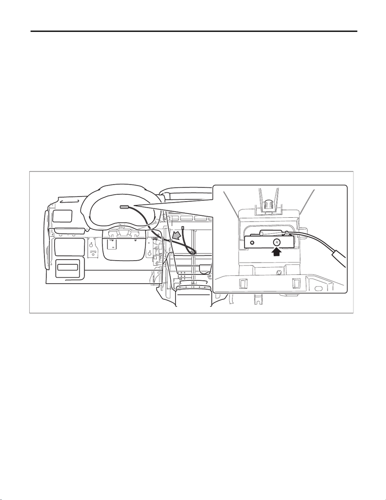

GPS Antenna

ENTERTAINMENT

14.GPS Antenna

A: REMOVAL

1) Disconnect the ground cable from battery. <Ref. to NT-5, BATTERY, NOTE, Note.>

NOTE:

For models other than STI model, disconnect the ground terminal from battery sensor.

2) Remove the combination meter assembly. <Ref. to IDI-13, REMOVAL, Combination Meter.>

3) Remove the panel center assembly. <Ref. to EI-66, REMOVAL, Center Console.>

4) Remove the navigation assembly in the same manner as the removal procedure of the audio assembly.

<Ref. to ET-8, REMOVAL, Audio.>

5) Remove the GPS antenna assembly.

(1) Tie a string to the GPS antenna assembly connector on the navigation unit side.

NOTE:

A string makes operation easier during installation.

(2) Remove the screw and harness clamp, and pull out the GPS antenna assembly connector from the

combination meter side.

(3) When the GPS antenna assembly is pulled out, remove the string attached to the connector in step

(1).

B: INSTALLATION

CAUTION:

After installing the panel center assembly, check that the air vent grille of the panel center assembly

is inserted correctly into the air vent duct.

1) Install the GPS antenna assembly.

2) Install the navigation assembly.

3) Install the panel center assembly.

4) Install the combination meter assembly.

5) Connect the battery ground terminal. <Ref. to NT-5, BATTERY, NOTE, Note.>

NOTE:

For models other than STI model, connect the ground terminal to battery sensor.